# TP2 - Econometrics

# Part-2 : Simulating stationary linear processes

Before using economic or financial data, we propose to simulate autoregressive and moving average processes and to empirically evaluate their statistical properties. We will assume that the variables are centered in order to simplify the analysis.

## Exercise 1 : The autoregressive process

### 1. Generate a Gaussian white noise process of 1000 observations with zero mean of 0 and σu2 = 1

```r
library(forecast)
library(stats)
set.seed(123)
n <- 1000

#Generation du bruit blanc :
bruit_blanc <- rnorm(n, mean = 0, sd = 1)
```

### 2. We aim at simulating a second order stationary autoregressive process given by : yt = 0, 6yt−1 + 0, 2yt−2 + ut where ut ∼ N (0, σ2) (1) Use a “for” loop to generate the process given in (1). The initial condition can be set up to 0 ot to the first observation of the N(0, σ2).

```r
Yt_ar <- bruit_blanc[1:2] # On initialise l'AR avec les deux premières valeurs du bruit blanc
for(i in 3:n){
  Yt_ar[i] = 0.6*Yt_ar[i-1] + 0.2*Yt_ar[i-2] + bruit_blanc[i]
}
```

### 3. Plot the simulated process, its auto-covariance function, the autocorrelation function and the partial autocorrelation function as well. Are the results in line with the expectations ?

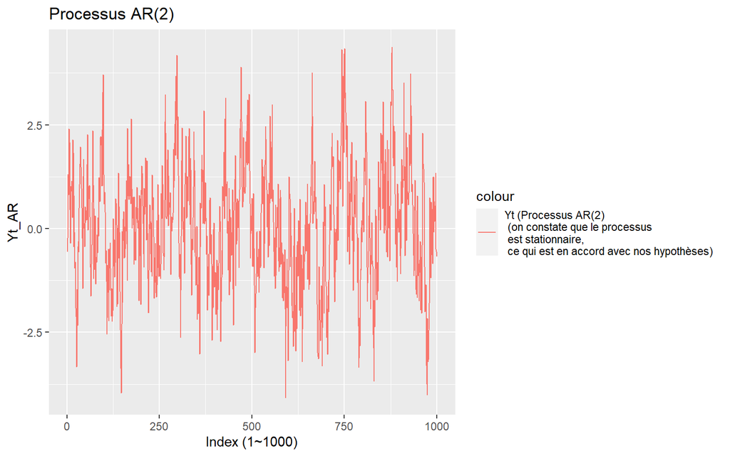

```r
library(ggplot2)
df <- data.frame(x = 1:1000, y = Yt_ar)
plot_AR2 <- ggplot(df,aes(x = df$x, y = df$y, col = "Yt (Processus AR(2) \n (on constate que le processus \n est stationnaire,\n ce qui est en accord avec nos hypothèses) ")) + geom_line() + xlab("Index (1~1000)") + ylab("Yt_AR") + ggtitle("Processus AR(2)")
plot_AR2
```

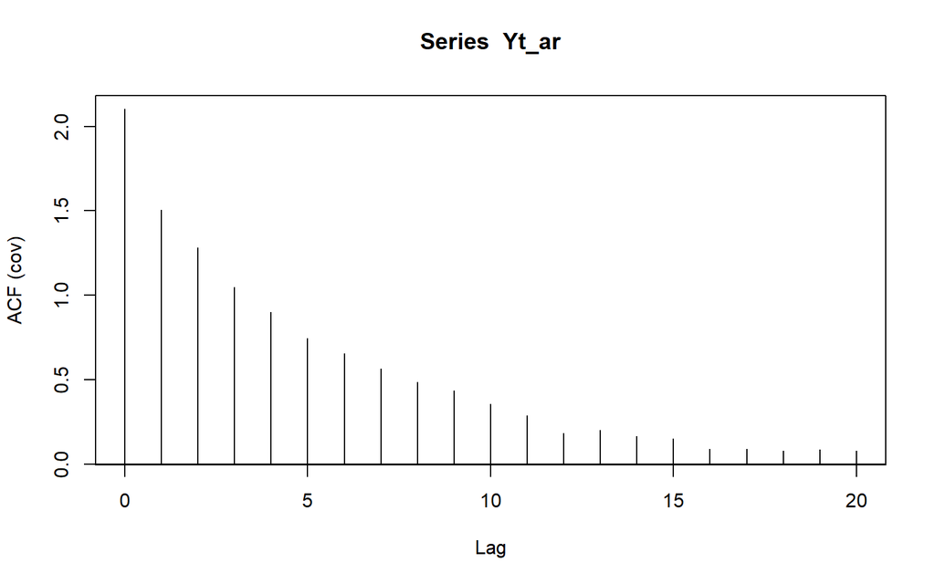

```r
auto_covariance_AR2 <- acf(Yt_ar, lag = 20, type = "covariance")
```

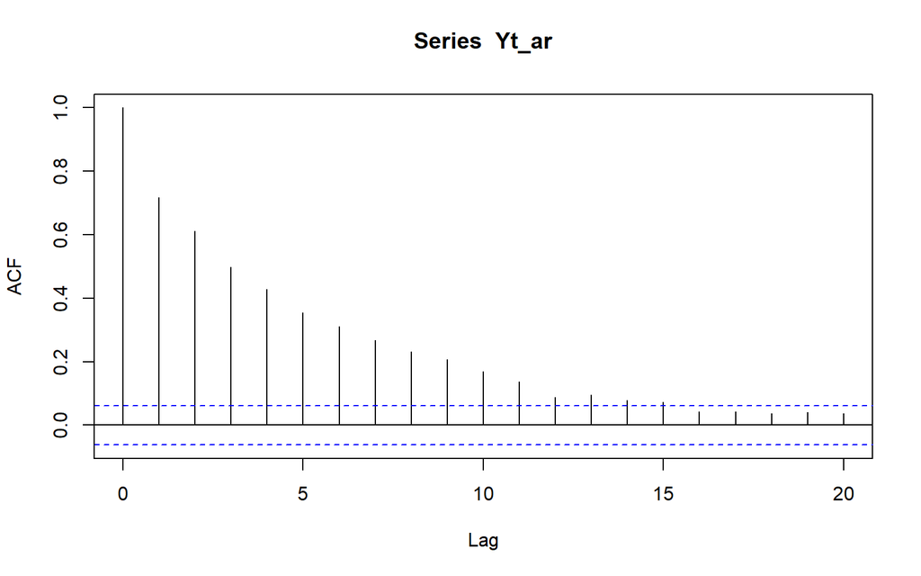

```r
auto_correlation_AR2 <- acf(Yt_ar, lag = 20, type = "correlation")
```

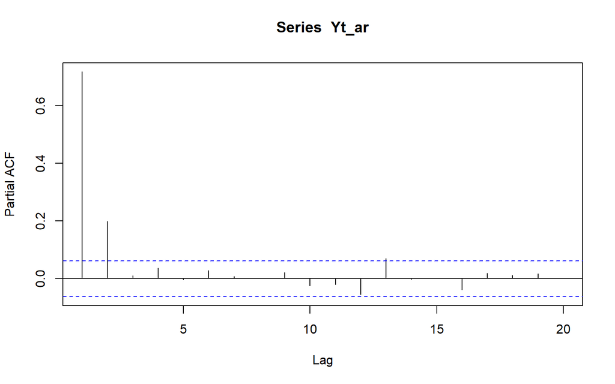

```r
pacf_AR2 <- pacf(x = Yt_ar, lag = 20)
```

### 4. Run and plot the Ljung-Box statistical test for 24 lags. Does the result of the test validate

your initial diagnosis.

```r
Ljung_Box <- Box.test(Yt_ar, lag = 24, type = "Ljung-Box")
p_value <- Ljung_Box$p.value
p_value
```

```
## [1] 0
```

> Le test de Ljung-Box test si l’autocorrélation du processsus est d’ordre supérieur à 1 (ie : si il y’a dépendance des yt,…,yt-k). On constate que la p-value du test est largement inférieure à 0.05 et même à 0.01 donc pour un niveau de confiance de 99%, On peut affirmer que les réalisations sont dépendantes.

### 5. Is the process given by 1 a stationary process ? Plot the root of the process within the unit circle.

What is your conclusion ?

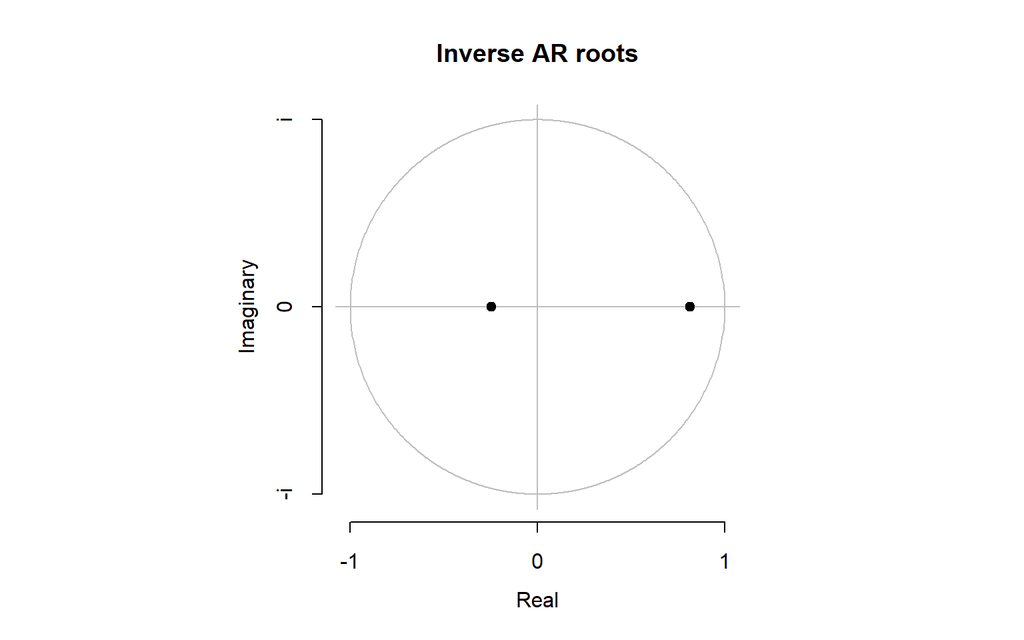

```r
circle <- arima(Yt_ar, order = c(2,0,0))
plot(circle)
```

## Exercise 2 : The moving average process

We move now to the moving average process and propose to simulate the following MA(2) process :

yt = ut + 0.5ut−1 + 0.3ut−2

### 1. Use a “for” loop to generate to generate the process given by the equation 1. Check our result using the auto.sim function available under R (if necessary load the package arima.sim).

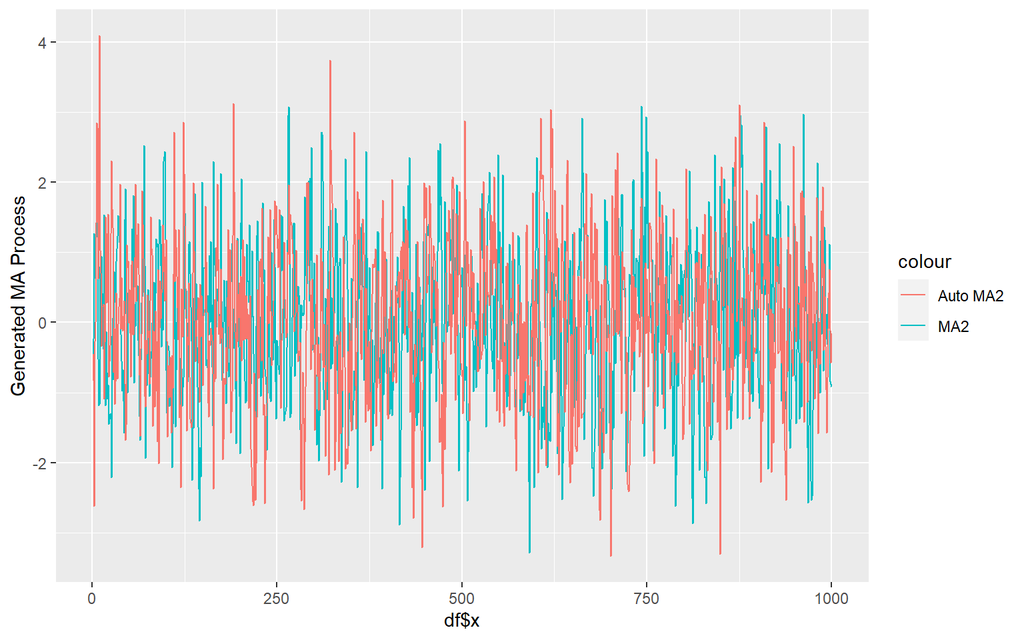

```r
set.seed(123)
wn <- rnorm(1000, 0, 1)
MA2 <- wn[1:2]
for(t in 3:1000){
  MA2[t] <- wn[t] + 0.5*wn[t-1] + 0.3*wn[t-2]
}

auto_MA2 <- arima.sim(list(order=c(0,0,2), ma= c (0.5, 0.3)), n = 1000, rand.gen = rnorm)

df <- data.frame(x = 1:1000, y = MA2, z = auto_MA2)
ggplot(data = df, aes(x = df$x, y = df$y, col = "MA2")) + geom_line() + geom_line(aes(y = df$z, col = "Auto MA2" )) + ylab("Generated MA Process")
```

```r
#Les valeurs initiales étant différentes, les processus ne sont pas superposés sur le graph
```

### 2. Plot the simulated process, its auto-covariance function and the autocorrelation function as well. Are the results in line with the expectations ?

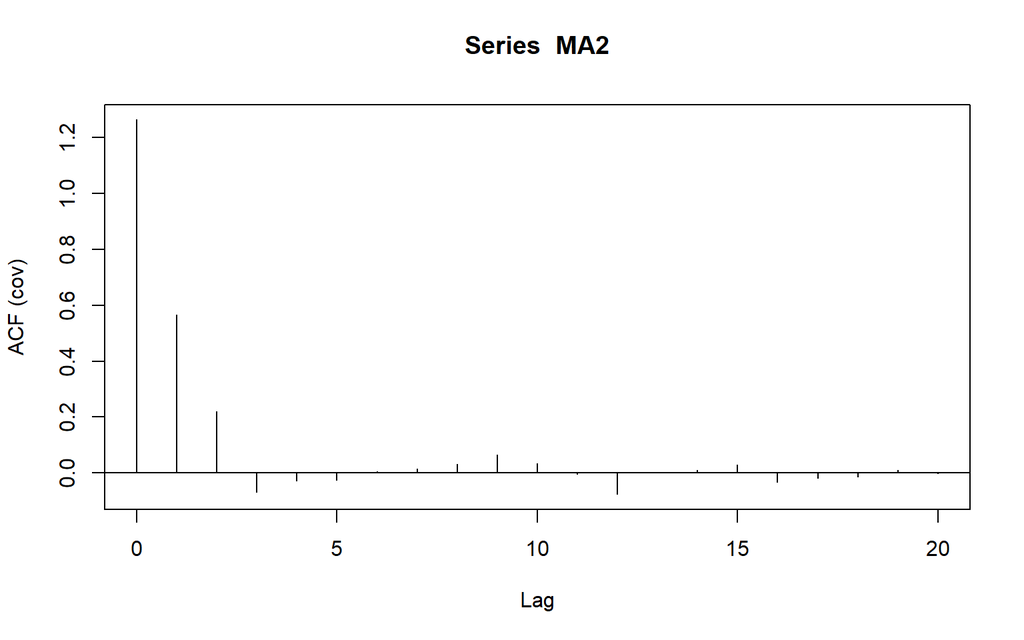

```r
auto_covariance_MA2 <- acf(MA2, lag = 20, type = "covariance")
```

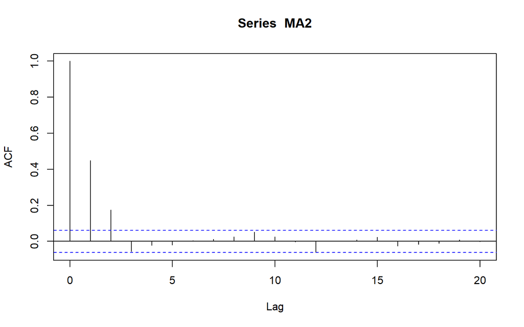

```r
auto_correlation_MA2 <- acf(MA2, lag = 20, type = "correlation")
```

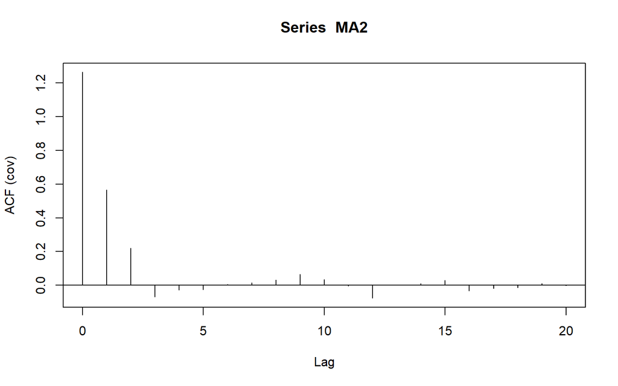

```r
plot(auto_covariance_MA2)
```

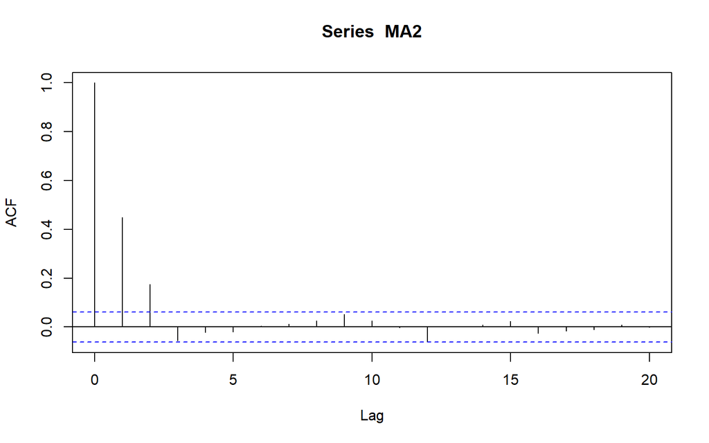

```r
plot(auto_correlation_MA2)
```

### 3. Run and plot the Ljun-Box (78) statistical test for 24 lags. Does the result of the test validate your first assessment.

```r
Ljung_Box2 <- Box.test(MA2, lag = 20, type = "Ljung-Box")
Ljung_Box2
```

```
##
##  Box-Ljung test
##
## data:  MA2
## X-squared = 245.7, df = 20, p-value < 2.2e-16
```

### 4. Is the process given by one a stationary process ? Why ? Is this process invertible ?

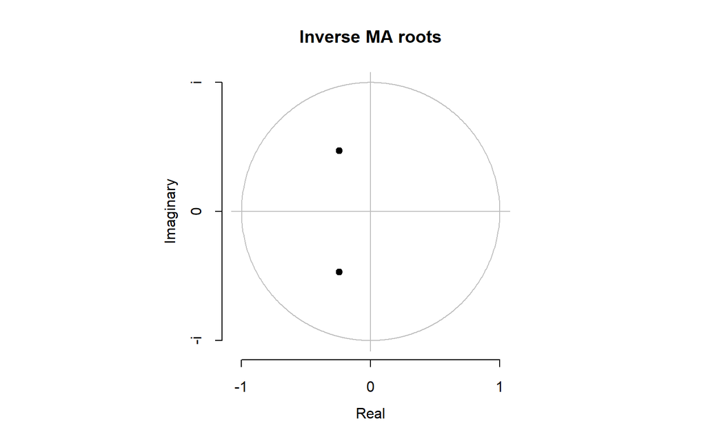

```r
circle <- arima(MA2, order = c(0,0,2))
plot(circle)
```

## Exercise 3 : simulating an ARMA model

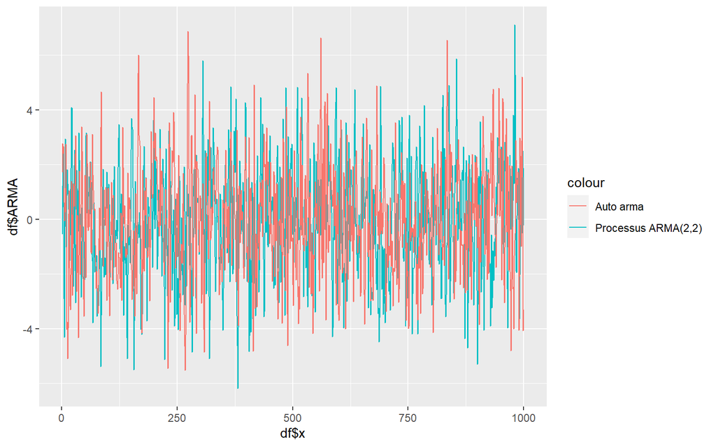

```r
#Generation du bruit blanc gaussien :
wn = rnorm(1000,0,1)
#Generation de du Processus ARMA
Yt_arma = wn[1:2]
for(t in 3:1000){
  Yt_arma[t] <- 0.6*Yt_arma[t-1]-0.25*Yt_arma[t-2] + wn[t] + 1.1*wn[t-1] - 0.28*wn[t-2]
}
df <- data.frame(x= 1:1000, ARMA= Yt_arma)
auto.arma22 = arima.sim(list(order=c(2,0,2), ma=c (1.1, -0.28), ar=c(0.6,-0.25)), n=1000 , n.start = NA)
arma <- ggplot(df, aes(x = df$x, y = df$ARMA, col = "Processus ARMA(2,2)")) + geom_line() + geom_line(aes(y = auto.arma22, col = "Auto arma"))
arma
```

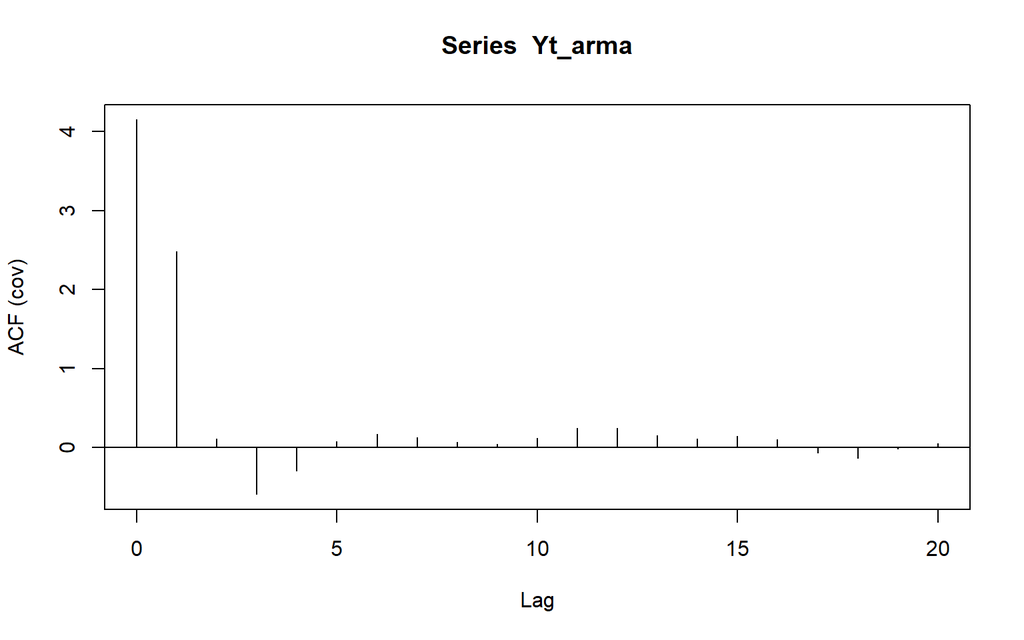

```r
acf(Yt_arma, lag = 20, type = "covariance")
```

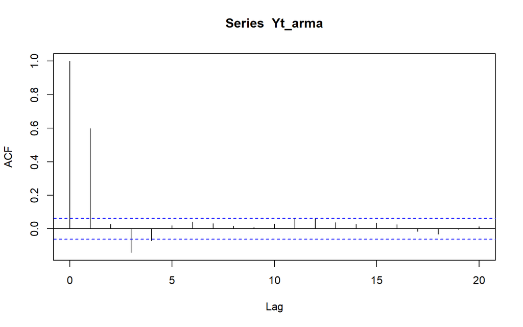

```r
acf(Yt_arma, lag = 20, type = "correlation")
```

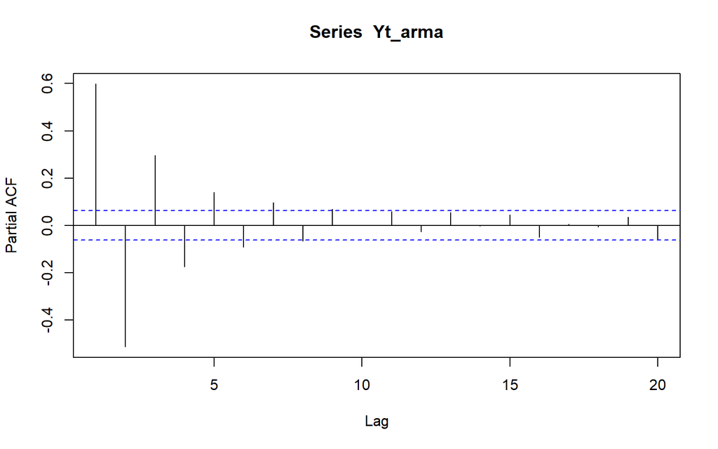

```r
pacf(Yt_arma, lag = 20)
```

```r
Ljung_Box3 <- Box.test(Yt_arma, lag = 20, type = "Ljung-Box")
Ljung_Box3
```

```
##
##  Box-Ljung test
##
## data:  Yt_arma
## X-squared = 401.89, df = 20, p-value < 2.2e-16
```

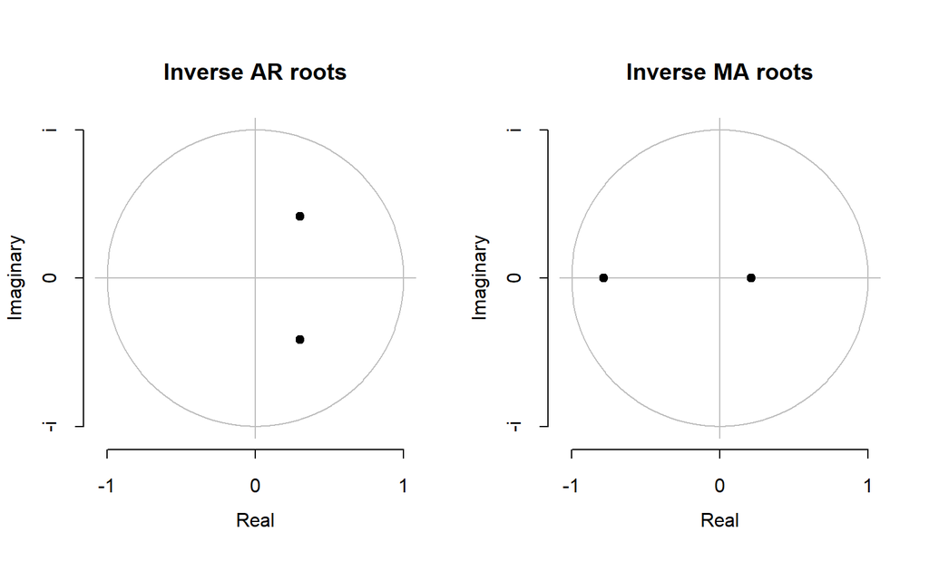

```r
circle <- arima(Yt_arma, order = c(2,0,2))
plot(circle)
```